# AS2017372_Egypt

N.M.Gamage

7/5/2020

# COVID-19 PANDEMIC IN EGYPT

## **Introduction**

### visualization of the location

Egypt is located on the northeast corner of the African continent. It is bordered by Libya to the west,Sudan to the south,the Red Sea to the east,and the Mediterranean Sea to the north.

[figure not shown]

Egypt has the largest,most densely settled population among the Arab countries. The total area of the country covers approximately one million square kilometers.However,much of the land is desert, and only 7.7 per cent of Egypt’s area is inhabited. The Egyptian government has a policy of land reclamation and fostering of new settlements in the desert. Despite theses efforts,the majority of Egyptians live either in the Nile Delta located in the north of the country or in the narrow Nile Valley south of Cairo. Administratively, Egypt is divided into 27 governorates.the four Governorates (Cairo,Alexandria,Port Said,and Suez) have no rural population. Each of the other 23 governorates is subdivided into urban and rural areas.

### climate condition

The Egyptian summer is hot and dry in most of the country, and humid in the Delta and along the Mediterranean Coast. In recent years the humidity has spread to Cairo, and the city swelters in August. Winter is mild with some rain. But usually, it is bright, sunny days with cold nights.

In the coastal region average annual temperature range from a maximum of 37°C(99°F) to a minimum of 14°C(57°F). Wide variations of temperature occur in the deserts, ranging from a maximum of 46°C(114°F), during daylight hours, to a minimum of 6°C(42°F) after sunset. During the winter season, desert temperature often drop to 0°C(32°F).

The most humid area is along the Mediterranean coast, where the average annual rainfall is about 200nm. Precipitation decreases rapidly to the south. Cairo receives on average only about 26nm of rain each year and in many desert locations it may rain only once in several years.

### Lock-down status of the country

On 12 January 2020, the World Health Organization (WHO) confirmed that a novel corona virus was the cause of a respiratory illness in a cluster of people in Wuhan city, Hubei Province, China, which was reported to the WHO on 31 December 2019.The virus was confirmed to have reached Egypt on 14 February 2020.

There was never much chance of social distancing in Cairo, a city more populous than most countries. Buses fill to overflowing, passengers dangling out of open doors. Millions live in informal settlements with streets barely wide enough for a sedan.The situation is closely and continuously monitored by a special committee chaired by the Prime Minister and all decisions are announced to the public. All decisions have a definite time duration, and are revised periodically, depending on the escalation of the issues. And indeed, unlike many other Arab countries, Egypt did not try to impose a strict lock-down. There is a night-time curfew; busy spaces like restaurants and cafes are shut. But public transport is running, factories are humming and shops keep at least limited opening hours.

The government is currently considering relaxing the lock down procedures, consistent with the global trend worldwide, in order to avoid prolonged significant economic downturn. In this respect, the government issued a reopening guidelines and protocols pamphlet to provide safety instructions for individuals, corporate and government institutions during the Covid-19 prevalence.

### Actions taken by the Government

The immediate actions taken are broadly classified into:

1. Health sector initiatives
2. Liquidity measures
3. Fiscal actions
4. Debt restructing actions

#### Health sector initiatives

These include efforts of social distancing and funds to support the health situation as follows;

- Temporary closure of all schools, universities, airports, rituals, restaurants and coffee shops (allowing for restricted delivery service), government institutions, with the exception of the ones providing direct health and food services/products, and all sort of public meetings, workshops or exhibitions during the period from mid-March till April 23rd, 2020, subject to extension depending on the situation. The only exceptions are groceries, supermarkets, pharmacies and hospitals/health centers. Starting from April 23rg, 2020, and until further notice, the schools, universities, airports and religious places shall remain closed, however, other retail activities, including shopping malls, are allowed to re-open with fixed closing hours (5 pm).
- Lately hotels were allowed to re-open, provided they abide by strict hygiene measures stipulated by the government, at 25% occupancy rate in May and 50% occupancy rate in June. However, all group activities, events, weddings and night club/entertainment activities are banned, till further notice.
- Impose nationwide night-time curfew and stop all types of mass transportation during the curfew period, from 7pm to 6 am until end of March, 2020, which was later relaxed to be from 8pm to 6 am until April 23rd, 2020, then further relaxed from 9 pm to 6 am from April 23rd till further notice.
- Measures to limit the number of government employees going to work and encouraging through a media campaign and speeches by Prime Minister and President for virtual remote working, social distancing and staying home. Currently, this is being replaced by measures and campaign to live safely with the virus.
- Provide direct monetary support amounting to EGP 187.6 million to the Ministry of Health, directed to both medical supplies and preventive measures, and bonuses to workers in the health care system. The government announced that 2% of GDP shall be directed to the health sector.
- Prepare medical sites nationwide to anticipate the escalation of Covid-19 patients.
- Double the contribution percentage to public expenditure on health in the national budget.

#### Liquidity measures

These refer to measures to increase liquidity in the market at both national and sector level, as follows;

- A USD 2.7 billion loan was requested and granted by the IMF, as an emergency support.
- Reduce the overnight deposit and lending rate and the discount rate by 3% at once in order to create finance accessibility and reduce the cost of borrowing.
- Provide support to the most affected sectors, to include.
- Allocate EGP 50 billion loan fund to be directed to the tourism sector at subsidized interest rate for new and expansion projects.
- Provide credit facility to pay employees’ salaries in the tourism sector to be repaid on a period of 2 years, with grace period of 6 months.
- Exclude necessity goods from need to raise 100% cash cover for importation; Allocate EGP 20 billion fund to support the capital market.
- Subsidize the electricity and natural gas tariffs for the industrial sector.
- Reduce lending interest rate from 10% to 8% for the industrial and tourism sectors; Allow cash subsidies for daily earning workers amounting to EGP 500 per person.
- Facilitate access to credit facilities for working capital finance and removal of some credit restrictions.
- Payment of EGP 1 billion of export subsidy arrears and facilitate export procedures.

#### Fiscal actions

These include tax exemptions and public expenditure at both national and sectoral levels;

- Proceed with mega infrastructural projects.
- Provide 3 month tax relief for Real Estate taxes for tourism and industrial sectors.
- Allow 3 months installments to settle income tax for corporate companies for all affected sectors, during the period April to June, 2020, instead of one-time settlement in April.
- Allow delay in submission for individual tax reports to April 9th from March 31st.
- Increase the exemption tax limit for employees from EGP 8,000 to EGP 15,000.
- Raise the annual raise of public sector and state employees by 7% and 12%, respectively and for pensions by 14%.
- Tax reduction for the capital market to include removal of stamp duties, postponing capital gains to January 2022, and exemption for foreign investors and reductions of dividends taxes from 10% to 5%.

#### Debt restructing actions

- Delay of settling credit dues for individual banking loans (retail) for a period of 6 months and increase the monthly amount of loan repayment from 30% to 50% of monthly income.
- Removal ATM withdrawal limits for credit cards and principal dues for credit cards for a period of 6 months.
- Initiation of debt relief for amounts at risk of default on debt with amounts less than one million EGP.
- Allow grace period for mortgage lenders, factoring and leasing companies for a period of 6 months.
- Write-off EGP 17 billion from 226 distressed firms.

## **Data Exploration**

```r
egypt_corona <- coronavirus %>% filter(country == "Egypt")
egypt_corona_new<-egypt_corona %>%
separate(date,into=c("year","month","day"),sep="-")
egypt_corona_new<-egypt_corona_new %>%
  mutate(month=if_else(month=="01","Jan",if_else(month=="02","Feb",
    if_else(month=="03","Mar",
            if_else(month=="04","Apr","May"))
  )))
head(egypt_corona_new)
```

```
  year month day province country lat long      type cases
1 2020   Jan  22            Egypt  26   30 confirmed     0
2 2020   Jan  23            Egypt  26   30 confirmed     0
3 2020   Jan  24            Egypt  26   30 confirmed     0
4 2020   Jan  25            Egypt  26   30 confirmed     0
5 2020   Jan  26            Egypt  26   30 confirmed     0
6 2020   Jan  27            Egypt  26   30 confirmed     0
```

In the world map Egypt can be shown as below.

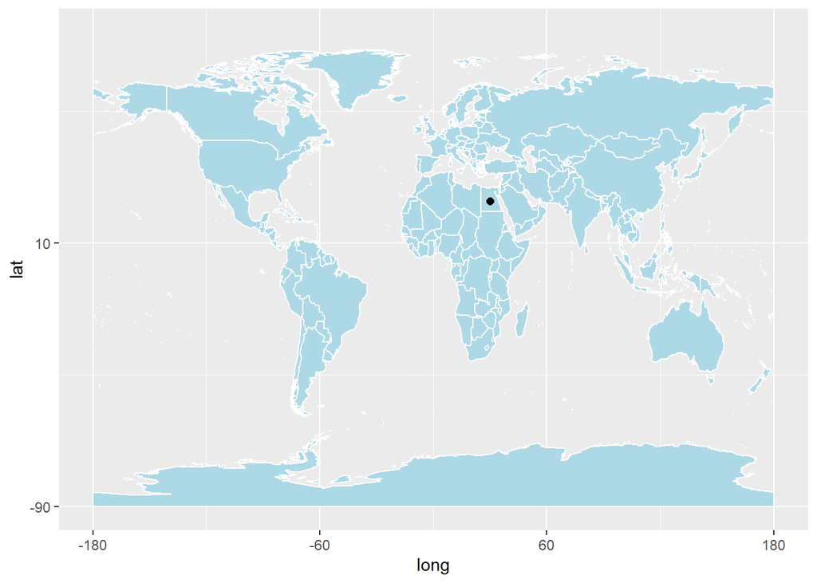

### visualization of COVID-19 cases

In here we analyzed the confirmed, death, recovered and active corona virus cases of Egypt using the data was collected from January to May.

#### Visualization of COVID-19 confirmed cases in Egypt

The following data represents the confirmed corona virus cases in Egypt.

```r
confirmed_egypt_corona<-egypt_corona %>% filter(type=="confirmed")
head(confirmed_egypt_corona)
```

```
        date province country lat long      type cases
1 2020-01-22            Egypt  26   30 confirmed     0
2 2020-01-23            Egypt  26   30 confirmed     0
3 2020-01-24            Egypt  26   30 confirmed     0
4 2020-01-25            Egypt  26   30 confirmed     0
5 2020-01-26            Egypt  26   30 confirmed     0
6 2020-01-27            Egypt  26   30 confirmed     0
```

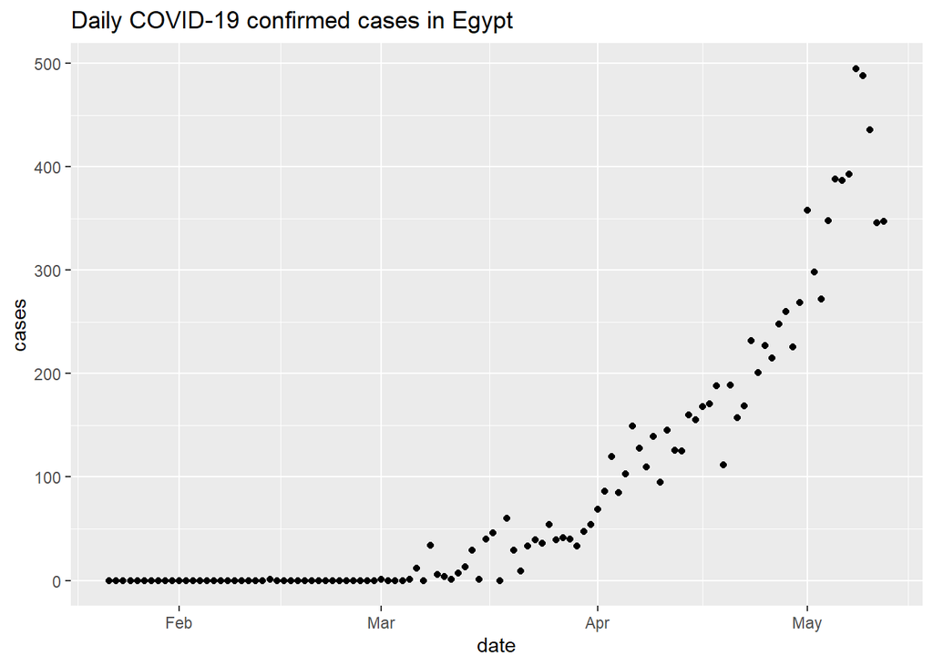

Figure 01: Daily COVID-19 confirmed cases in Egypt

The above figure shows the number of daily COVID-19 confirmed cases in Egypt from January to May. According to that there was no confirmed cases until mid of February. After that it was increased continuously and the maximum number of confirmed cases reported on May. It was near 500.

#### Visualization of COVID-19 death cases in Egypt

The following data represents the daily death cases in Egypt.

```r
death_egypt_corona<-egypt_corona %>% filter(type=="death")
head(death_egypt_corona)
```

```
        date province country lat long  type cases
1 2020-01-22            Egypt  26   30 death     0
2 2020-01-23            Egypt  26   30 death     0
3 2020-01-24            Egypt  26   30 death     0
4 2020-01-25            Egypt  26   30 death     0
5 2020-01-26            Egypt  26   30 death     0
6 2020-01-27            Egypt  26   30 death     0
```

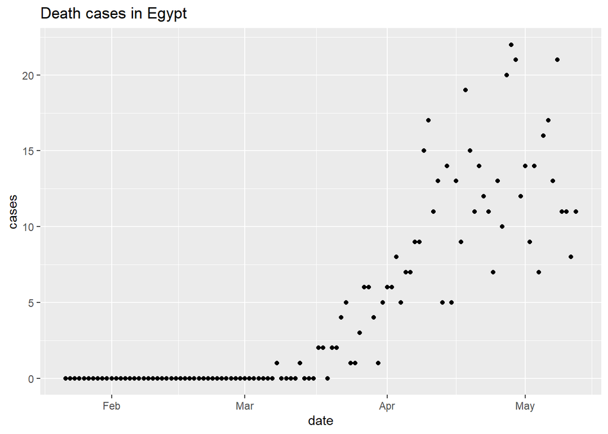

Figure 02:Daily COVID-19 death cases in Egypt

The above figure implies the corona virus death cases of Egypt from January to May. It shows that there were no corona virus death cases until the month of March.The first death case was found on March. After that the death cases increased and the maximum number of death cases reported on end of April.

#### Visualization of recovered cases

The following data represents the recovered cases in Egypt.

```r
recovered_egypt_corona<-egypt_corona %>% filter(type=="recovered")
head(recovered_egypt_corona)
```

```
        date province country lat long      type cases
1 2020-01-22            Egypt  26   30 recovered     0
2 2020-01-23            Egypt  26   30 recovered     0
3 2020-01-24            Egypt  26   30 recovered     0
4 2020-01-25            Egypt  26   30 recovered     0
5 2020-01-26            Egypt  26   30 recovered     0
6 2020-01-27            Egypt  26   30 recovered     0
```

```r
summary(recovered_egypt_corona)
```

```
      date              province           country               lat
 Min.   :2020-01-22   Length:112         Length:112         Min.   :26
 1st Qu.:2020-02-18   Class :character   Class :character   1st Qu.:26
 Median :2020-03-17   Mode  :character   Mode  :character   Median :26
 Mean   :2020-03-17                                         Mean   :26
 3rd Qu.:2020-04-14                                         3rd Qu.:26
 Max.   :2020-05-12                                         Max.   :26
      long        type               cases
 Min.   :30   Length:112         Min.   : -6.00
 1st Qu.:30   Class :character   1st Qu.:  0.00
 Median :30   Mode  :character   Median :  0.00
 Mean   :30                      Mean   : 20.77
 3rd Qu.:30                      3rd Qu.: 32.25
 Max.   :30                      Max.   :163.00
```

```r
recovered_egypt_corona <- recovered_egypt_corona %>% mutate(cases = replace(cases, which(cases < 0), NA))
summary(recovered_egypt_corona)
```

```
      date              province           country               lat
 Min.   :2020-01-22   Length:112         Length:112         Min.   :26
 1st Qu.:2020-02-18   Class :character   Class :character   1st Qu.:26
 Median :2020-03-17   Mode  :character   Mode  :character   Median :26
 Mean   :2020-03-17                                         Mean   :26
 3rd Qu.:2020-04-14                                         3rd Qu.:26
 Max.   :2020-05-12                                         Max.   :26

      long        type               cases
 Min.   :30   Length:112         Min.   :  0.00
 1st Qu.:30   Class :character   1st Qu.:  0.00
 Median :30   Mode  :character   Median :  0.00
 Mean   :30                      Mean   : 21.01
 3rd Qu.:30                      3rd Qu.: 33.50
 Max.   :30                      Max.   :163.00
                                 NA's   :1
```

The above results shows that there is a negative value in recovered COVID-19 cases in Egypt.

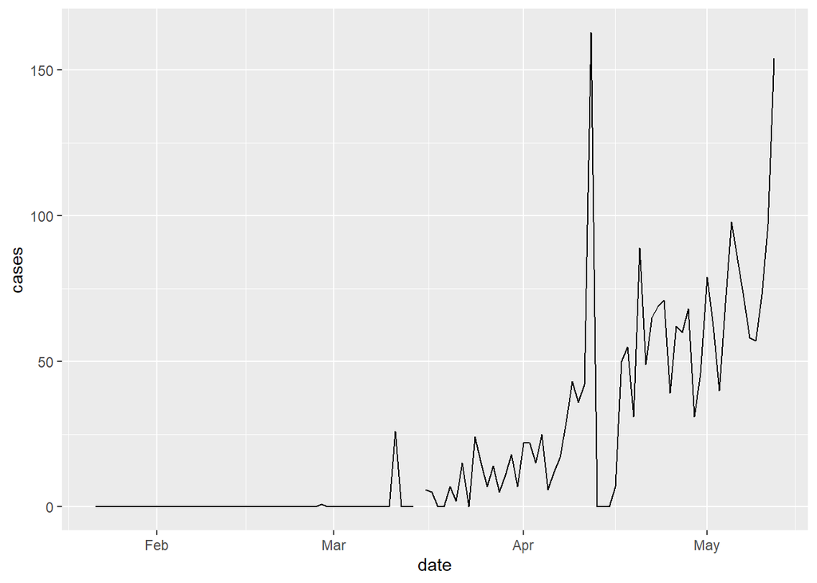

Figure 03:Time series plot of recovered cases in Egypt (without negative value)

The above figure shows a discontinuity in line.

To remove the discontinuity, first the negative value was identified.

```r
which(is.na(recovered_egypt_corona$cases))
```

```
[1] 54
```

54 is the negative value found in recovered cases.I used the average of 53rd and 55th to find the negative value.

```r
recovered_egypt_corona$cases[54] = mean(c(recovered_egypt_corona$cases[53], recovered_egypt_corona$cases[55]))
length(recovered_egypt_corona$cases)
```

```
[1] 112
```

I added a column col that indicates the desired color.

```r
recovered_egypt_corona$col <- as.factor(c(rep("black", 52),rep("red", 2), rep("black", 112-54)))
summary(recovered_egypt_corona)
```

```
      date              province           country               lat
 Min.   :2020-01-22   Length:112         Length:112         Min.   :26
 1st Qu.:2020-02-18   Class :character   Class :character   1st Qu.:26
 Median :2020-03-17   Mode  :character   Mode  :character   Median :26
 Mean   :2020-03-17                                         Mean   :26
 3rd Qu.:2020-04-14                                         3rd Qu.:26
 Max.   :2020-05-12                                         Max.   :26
      long        type               cases           col
 Min.   :30   Length:112         Min.   :  0.00   black:110
 1st Qu.:30   Class :character   1st Qu.:  0.00   red  :  2
 Median :30   Mode  :character   Median :  0.00
 Mean   :30                      Mean   : 20.85
 3rd Qu.:30                      3rd Qu.: 32.25
 Max.   :30                      Max.   :163.00
```

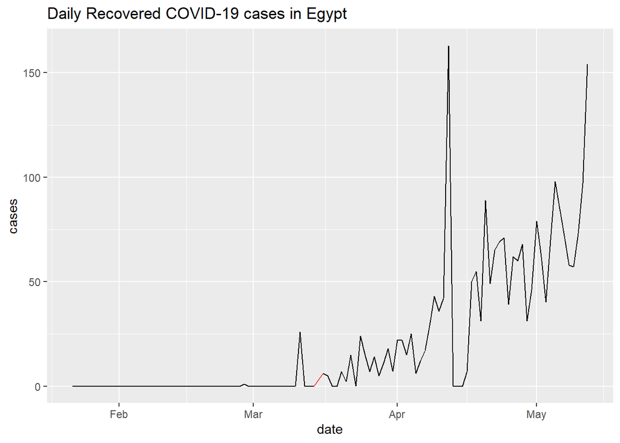

Figure 04: Daily recovered COVID-19 cases in Egypt(negative value is shown in red)

The above figure shows the number of recovered cases in Egypt during the time period January and May.It shows that the number of daily recovered cases increased with the time. The maximum number of daily recovered cases reported on April and it was more than 150. After the maximum daily recovered cases found, the cases suddenly went to zero.

#### Visualization of active COVID-19 cases in Egypt

```r
library(tidyr)
library(magrittr)
library(tidyverse)
egypt_corona_new1 <-egypt_corona %>%
pivot_wider(names_from = type,values_from = cases)
egypt_corona_new1
```

```
# A tibble: 112 x 8
   date       province country   lat  long confirmed death recovered
   <date>     <chr>    <chr>   <dbl> <dbl>     <int> <int>     <int>
 1 2020-01-22 ""       Egypt      26    30         0     0         0
 2 2020-01-23 ""       Egypt      26    30         0     0         0
 3 2020-01-24 ""       Egypt      26    30         0     0         0
 4 2020-01-25 ""       Egypt      26    30         0     0         0
 5 2020-01-26 ""       Egypt      26    30         0     0         0
 6 2020-01-27 ""       Egypt      26    30         0     0         0
 7 2020-01-28 ""       Egypt      26    30         0     0         0
 8 2020-01-29 ""       Egypt      26    30         0     0         0
 9 2020-01-30 ""       Egypt      26    30         0     0         0
10 2020-01-31 ""       Egypt      26    30         0     0         0
# ... with 102 more rows
```

```r
library(dplyr)
egypt_corona_new2<- egypt_corona_new1 %>%
  mutate(active=confirmed-recovered-death)
egypt_corona_new2
```

```
# A tibble: 112 x 9
   date       province country   lat  long confirmed death recovered active
   <date>     <chr>    <chr>   <dbl> <dbl>     <int> <int>     <int>  <int>
 1 2020-01-22 ""       Egypt      26    30         0     0         0      0
 2 2020-01-23 ""       Egypt      26    30         0     0         0      0
 3 2020-01-24 ""       Egypt      26    30         0     0         0      0
 4 2020-01-25 ""       Egypt      26    30         0     0         0      0
 5 2020-01-26 ""       Egypt      26    30         0     0         0      0
 6 2020-01-27 ""       Egypt      26    30         0     0         0      0
 7 2020-01-28 ""       Egypt      26    30         0     0         0      0
 8 2020-01-29 ""       Egypt      26    30         0     0         0      0
 9 2020-01-30 ""       Egypt      26    30         0     0         0      0
10 2020-01-31 ""       Egypt      26    30         0     0         0      0
# ... with 102 more rows
```

```r
library(dplyr)
egypt_corona_new3<-egypt_corona_new2 %>%
  mutate(active_total = cumsum(active),
                recovered_total = cumsum(recovered),
                death_total = cumsum(death))
egypt_corona_new3
```

```
# A tibble: 112 x 12
   date       province country   lat  long confirmed death recovered active
   <date>     <chr>    <chr>   <dbl> <dbl>     <int> <int>     <int>  <int>
 1 2020-01-22 ""       Egypt      26    30         0     0         0      0
 2 2020-01-23 ""       Egypt      26    30         0     0         0      0
 3 2020-01-24 ""       Egypt      26    30         0     0         0      0
 4 2020-01-25 ""       Egypt      26    30         0     0         0      0
 5 2020-01-26 ""       Egypt      26    30         0     0         0      0
 6 2020-01-27 ""       Egypt      26    30         0     0         0      0
 7 2020-01-28 ""       Egypt      26    30         0     0         0      0
 8 2020-01-29 ""       Egypt      26    30         0     0         0      0
 9 2020-01-30 ""       Egypt      26    30         0     0         0      0
10 2020-01-31 ""       Egypt      26    30         0     0         0      0
# ... with 102 more rows, and 3 more variables: active_total <int>,
#   recovered_total <int>, death_total <int>
```

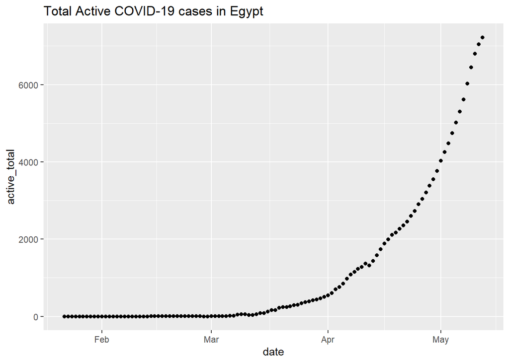

Figure 05: Total number of Active COVID-19 cases in Egypt

The above figure shows the total active COVIDD-19 cases in Egypt from January to May. According to that the total number of active cases reported increased continuously.

The confirmed, death and recovered COVID-19 cases in Egypt can be shown in a one graph as below.

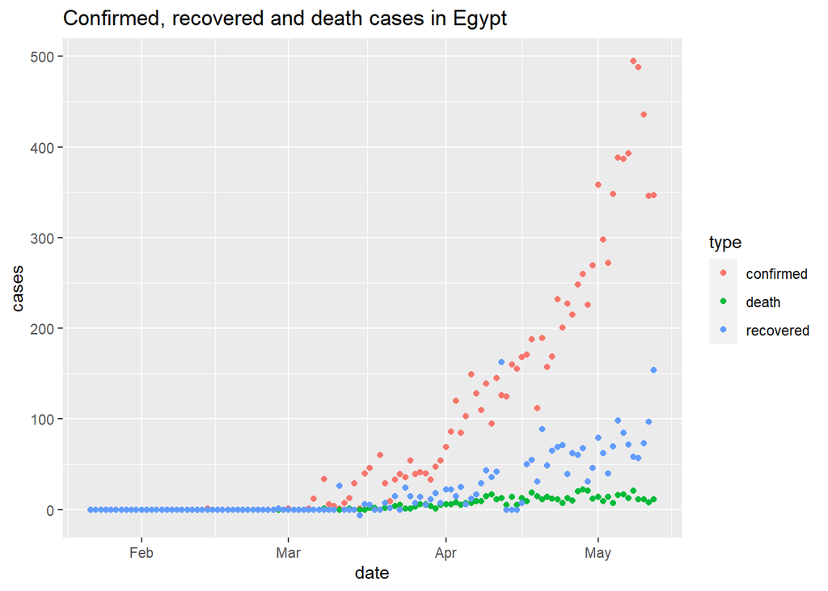

Figure 06: Daily COVID-19 confirmed, recovered and death cases in Egypt

This shows that when the daily confirmed cases increased, number of recovered cases also increased more than death cases.

The total number of cases can be summarized as below.

```r
library(tidyr)
egypt_corona %>%
  select( type, cases) %>%
  group_by( type) %>%
  summarise(total_cases = sum(cases)) %>%
  pivot_wider(names_from = type,values_from = total_cases) %>%
  arrange(-confirmed)
```

```
# A tibble: 1 x 3
  confirmed death recovered
      <int> <int>     <int>
1     10093   544      2326
```

This shows that the total number of confirmed cases was 10093 from January to May. Out of them 544 death cases was found and 2326 were recovered. Therefore the total number of active cases is 7223.

### Comparing the COVID-19 cases with other countries

Egypt shares maritime borders with Cyprus, Greece and Turkey in North through the Mediterranean sea. Jordan and Saudi Arabia have as well maritime borders with Egypt in the east via the Red sea. Therefore, Saudi Arabia is neighboring country of Egypt. On the 2nd of March the first case was found in Saudi Arabia. After that it was spread all over the country.

At the beginning of December 2019, the public health experts around the globe were understood this corona virus appeared in Wuhan, China. It has since infected thousands across the globe, and the World Health Organization declared it a pandemic, which refers to how far it’s spread.There are large outbreaks of the disease in multiple places and the United States has the worst outbreak of any country in the world.

Therefore to compare the corona virus pandemic in Egypt, we choose Saudi Arabia as the neighboring country, China as the beginning of virus and US as having the worst outbreak from the virus.

In this part, we compare the corona virus cases of Egypt with Saudi Arabia, China and US.

### Comparison of confirmed daily COVID-19 cases in Egypt with Saudi Arabia, China and US

First the confirmed cases of three countries were selected.

```r
corona_nw <-filter(coronavirus,country %in% c( "Saudi Arabia","Egypt","China","US"))
head(corona_nw)
```

```
        date province country lat long      type cases
1 2020-01-22            Egypt  26   30 confirmed     0
2 2020-01-23            Egypt  26   30 confirmed     0
3 2020-01-24            Egypt  26   30 confirmed     0
4 2020-01-25            Egypt  26   30 confirmed     0
5 2020-01-26            Egypt  26   30 confirmed     0
6 2020-01-27            Egypt  26   30 confirmed     0
```

```r
confirmed_corona_nw<-corona_nw %>% filter(type=="confirmed")
head(confirmed_corona_nw)
```

```
        date province country lat long      type cases
1 2020-01-22            Egypt  26   30 confirmed     0
2 2020-01-23            Egypt  26   30 confirmed     0
3 2020-01-24            Egypt  26   30 confirmed     0
4 2020-01-25            Egypt  26   30 confirmed     0
5 2020-01-26            Egypt  26   30 confirmed     0
6 2020-01-27            Egypt  26   30 confirmed     0
```

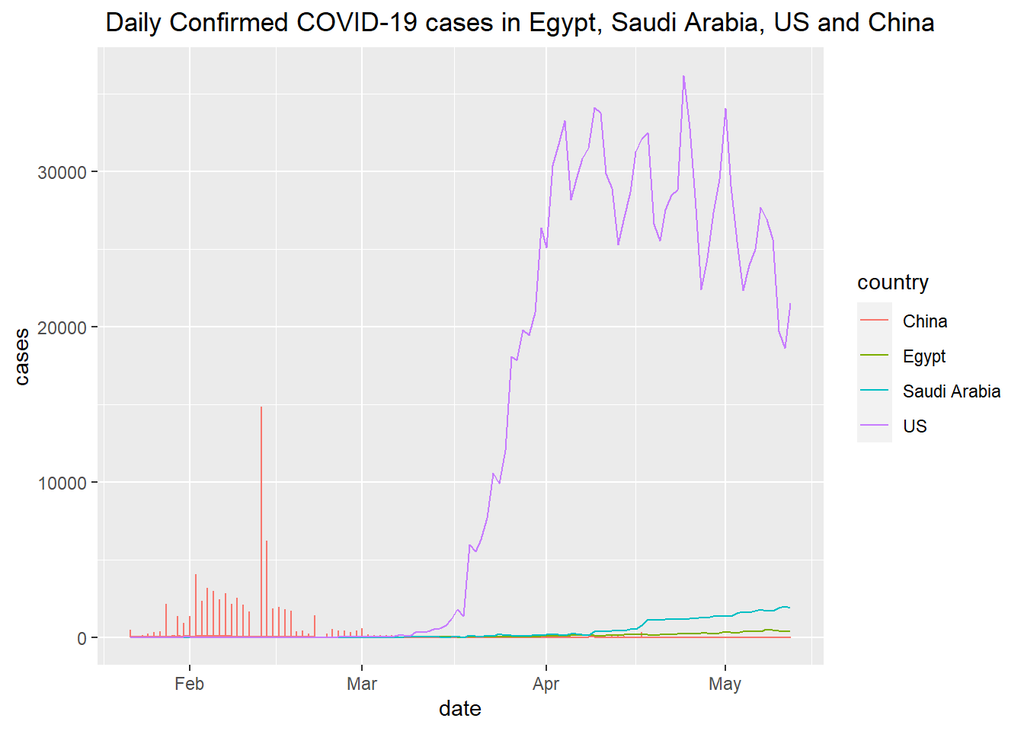

```r
library(ggplot2)
```

Figure 07:Daily COVID-19 confirmed cases in Egypt,china and US

Figure 07 shows that the confirmed cases of Egypt was quite increasing when compared to China between mid of March to May. when comparing with Saudi Arabia the confirmed cases were high until the first week of April. According to US the number of cases were very low. It can be see that the number of confirmed cases of US is very higher after March compare to Egypt, China and US.

### Comparison of daily COVID-19 death cases in Egypt with Saudi Arabia, China and US

First the death cases of three countries were selected.

```r
death_corona_nw<-corona_nw %>% filter(type=="death")
head(death_corona_nw)
```

```
        date province country lat long  type cases
1 2020-01-22            Egypt  26   30 death     0
2 2020-01-23            Egypt  26   30 death     0
3 2020-01-24            Egypt  26   30 death     0
4 2020-01-25            Egypt  26   30 death     0
5 2020-01-26            Egypt  26   30 death     0
6 2020-01-27            Egypt  26   30 death     0
```

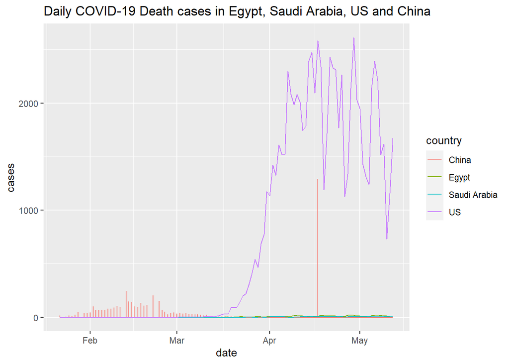

Figure 08: Daily COVID-19 death cases in Egypt,China and US

According to the above figure number of death cases found in Egypt were very small in the time period of January to May comparing with China and US. But the number of death cases of Saudi Arabia is very similar to Egypt. It can be see that the number of death cases of US is very higher after March compare to Egypt, China and US.

### Comparison of daily recovered COVID-19 cases in Egypt with Saudi Arabia, China and US

First the recovered cases of three countries were selected.

```r
recovered_corona_nw<-corona_nw %>% filter(type=="recovered")
head(recovered_corona_nw)
```

```
        date province country lat long      type cases
1 2020-01-22            Egypt  26   30 recovered     0
2 2020-01-23            Egypt  26   30 recovered     0
3 2020-01-24            Egypt  26   30 recovered     0
4 2020-01-25            Egypt  26   30 recovered     0
5 2020-01-26            Egypt  26   30 recovered     0
6 2020-01-27            Egypt  26   30 recovered     0
```

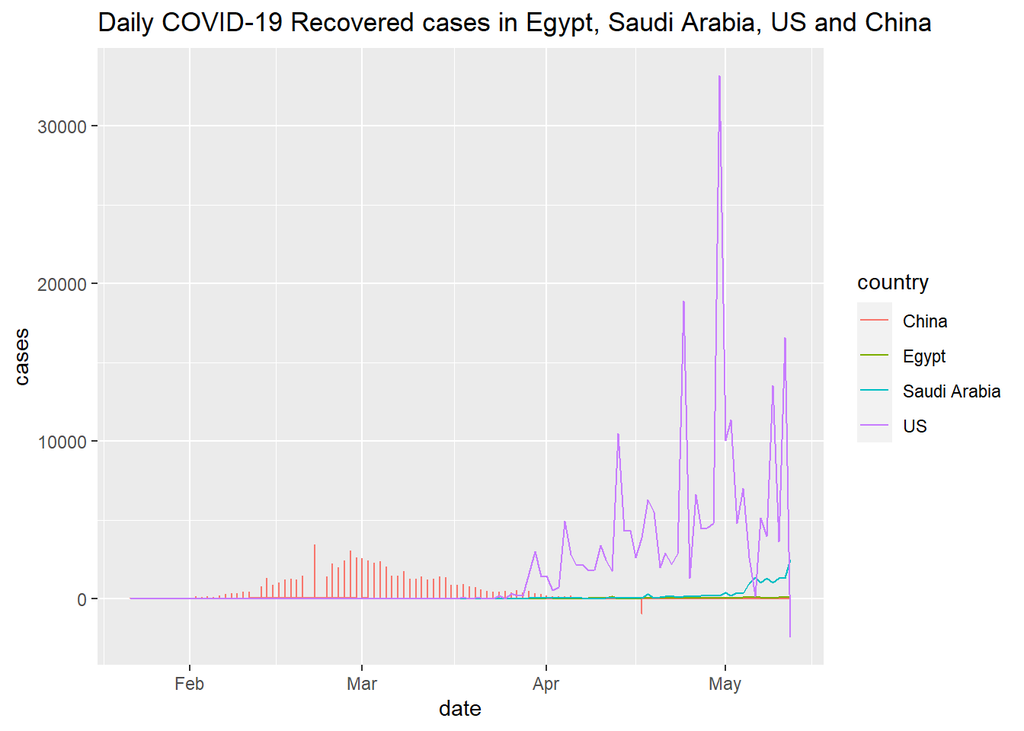

Figure 09:Daily COVID-19recovered cases in Egypt,China and US

Figure 09 shows the number of recovered corona virus cases of Egypt, China, Saudi Arabia and US from January to May. when comparing with Saudi Arabia the number of recovered cases were very similar but after April the cases of Egypt were lower than Saudi Arabia. It can be see that the number of recovered cases of US is very higher after March compare to Egypt, China and US.

## **Conclusions and Discussion**

According to the data taken from January to May of Egypt, there was a discontinuity point(negative value) in the daily COVID-19 recovered cases of Egypt. Instead of keeping this negative value in the data set, it was removed and the time series plot to the remaining data was obtained (figure 03). After that the negative value was imputed using average of one before negative value and one after negative value. Then the time series plot was designed to recovered daily COVID-19 cases in Egypt (figure 04) and the negative value was shown in red color. After the first case of Egypt was found on 14th of February, the government was taken lots of actions to control the virus. But they did not completely lock-down the country and only nighttime curfew was announced from 25th of March. Even these actions were done the daily confirmed cases were increased with the time. The first death case was found in Egypt after 3 weeks of finding the first confirmed case. Based on this data total number of COVID-19 were found as 10093 during January to May. Out of them 544 death cases were found and the number of recovered cases were 2326. The overall percentage of recovering from COVID-19 cases can be obtained as approximately 23%. Compared to other countries, the COVID-19 outbreak in Egypt is not much worse than US and China. It is quite similar to the outbreak in Saudi Arabia until the month of April. There are several limitations to keep in mind when interpreting the results of this study. Due to limited laboratory capacity, the actual epidemic may not be reflected by counts of laboratory confirmed cases reported. Sometimes, the government may be hide the actual counts of cases.Due to these reasons our findings can be change.

## **References**

- https://egyptindependent.com/egypt-yet-to-see-peak-in-coronavirus-cases-health-minister/
- https://www.economist.com/middle-east-and-africa/2020/05/23/egypt-chose-a-looser-lockdown-its-economy-is-still-in-crisis
- https://www.garda.com/crisis24/news-alerts/353986/egypt-authorities-ease-covid-19-restrictions-update-29
- https://www.care.gov.eg/default.html
- https://gisanddata.maps.arcgis.com/apps/opsdashboard/index.html#/bda7594740fd40299423467b48e9ecf6
- https://ourworldindata.org/coronavirus-testing
- https://theconversation.com/the-bar-necessities-5-ways-to-understand-coronavirus-graphs-135537
- https://github.com/CSSEGISandData/COVID-19
- https://ocean.sagepub.com/coronavirus
- https://rviews.rstudio.com/2020/03/05/covid-19-epidemiology-with-r/
- https://analyticsindiamag.com/coronavirus-package-in-now-available-for-r-programming-language/
- https://english.aawsat.com/home/article/2299761/egypt-impose-strict-lockdown-measures-control-covid-19